# Client Satisfaction Report

2019-2020 Survey Results - With Outliers

**Department Participant Comparison by Quarter**

Participants were selected by random as they were in the Fall. A program was used to simulate 15,000 random draws to determine what random draw would result in the fewest overlaps. This reduced the overlaps by about half (from 26 to 13). The distributions of participants by department is shown in the chart below; the Fall and Winter surveys had approximately the same distrubution. Because the survey does not collect email addresses, we do not know what the distribution of *responses* was relative to the participants.

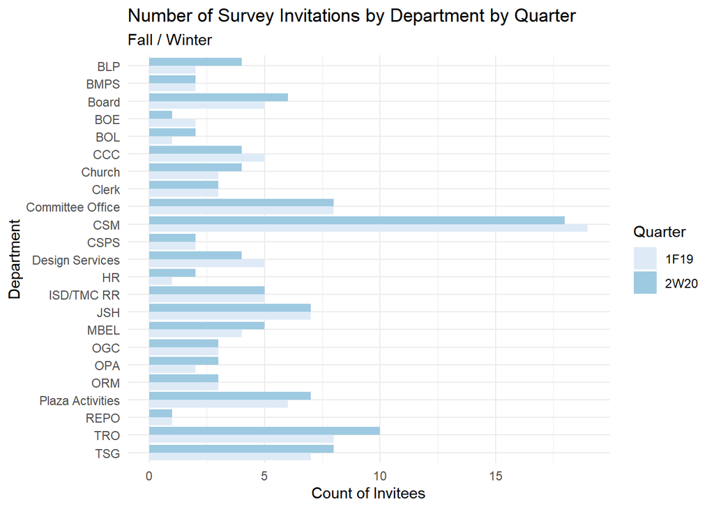

**Recap of Survey Questions**

- 1A. TSG representatives are always able to understand my problems / needs
- 1B. TSG representatives ask the right questions and listen to my input
- 1C. TSG representatives stay in touch until my problems are resolved or my needs are met
- 2A. TSG representatives always have the knowledge to address my needs
- 2B. TSG representatives address my needs completely and professionally
- 3X. TSG representatives always resolve my needs or problems within my required time-frames

**Summary of Quarter 1 and 2 Results (Fall, 2019 and Winter, 2020)**

Scores across the board were lower - for all questions, for all groups. The one group affected least by this was B&MPS, followed by the Service Desk. They also scored the highest in the Fall Survey.

This decrease in scores was attributed to combination of small sample size (41) and the presence of two highly negative responses as shown below:

Summary of Lowest Responses  
*Responder: 46 | Responses: 36 | Total Score: 98 } Average Score: 2.7*  
*Responder: 49 | Responses: 36 | Total Score: 42 | Average Score: 1.2*

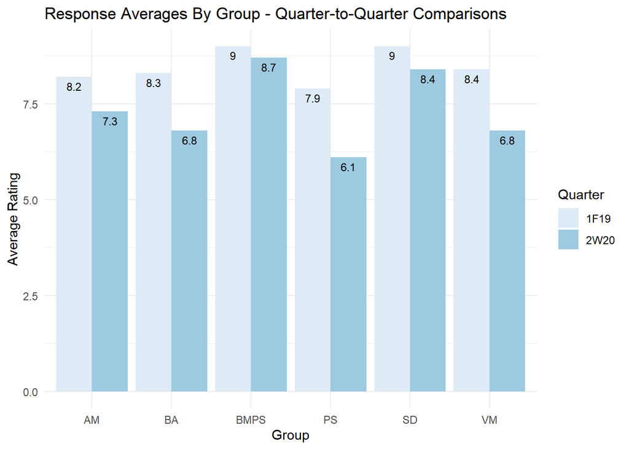

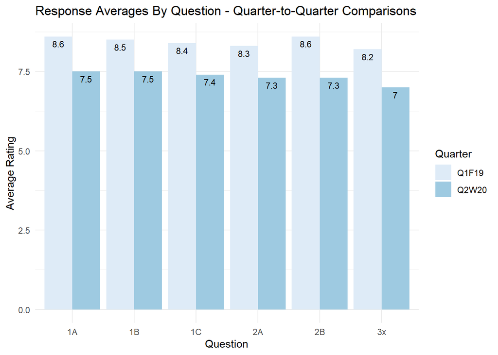

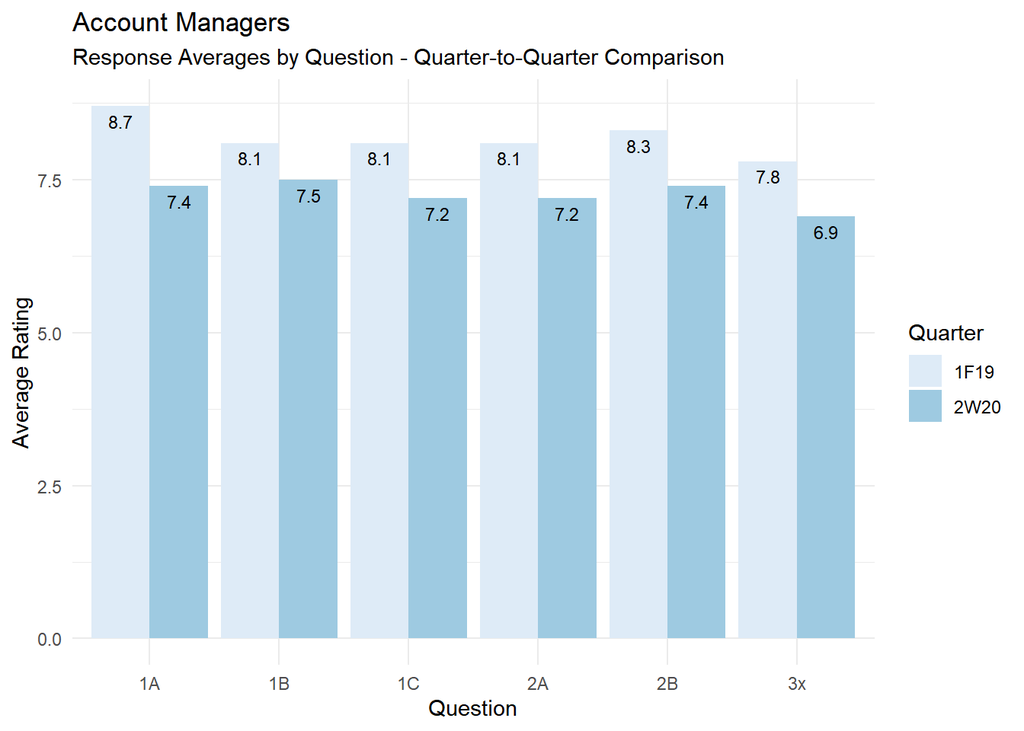

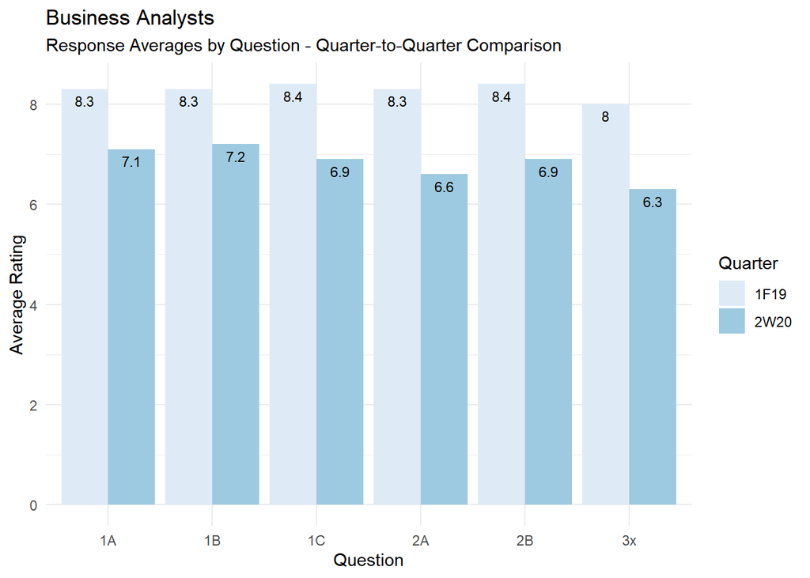

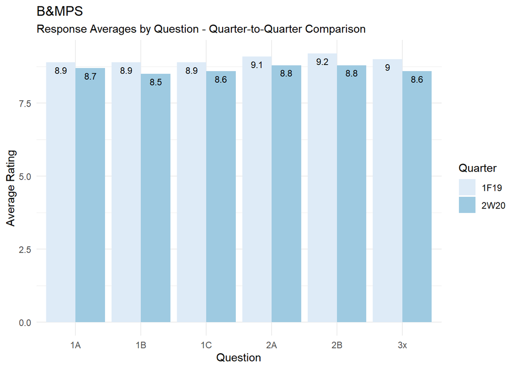

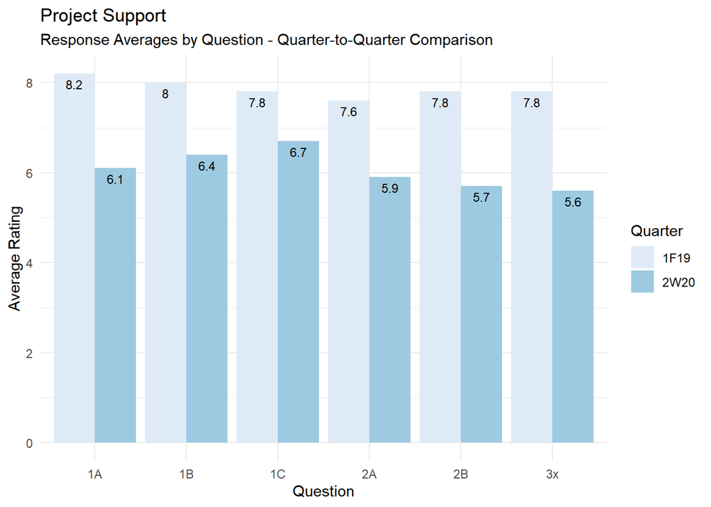

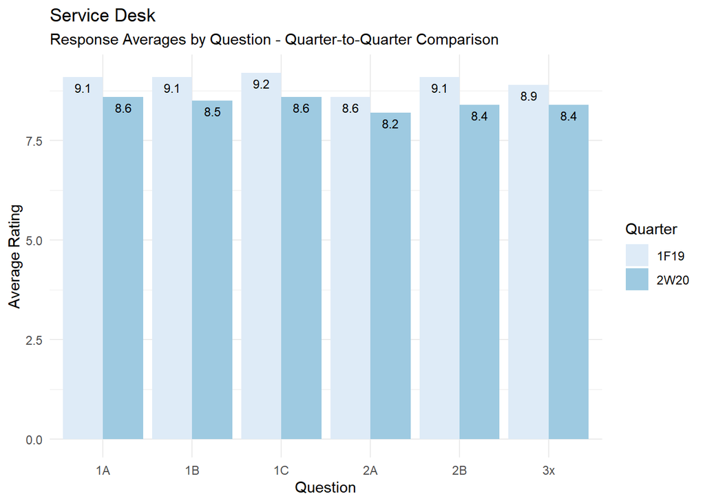

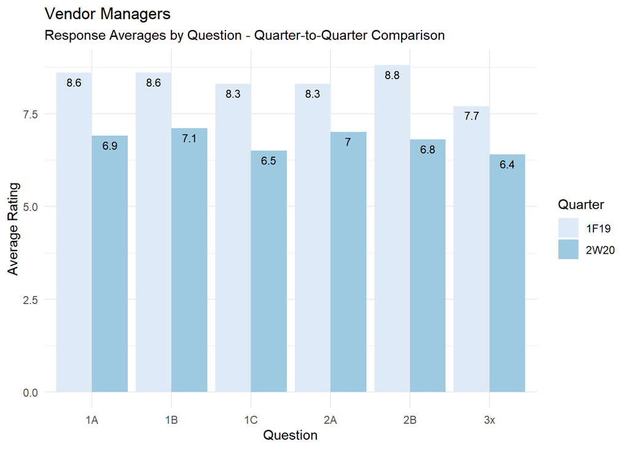

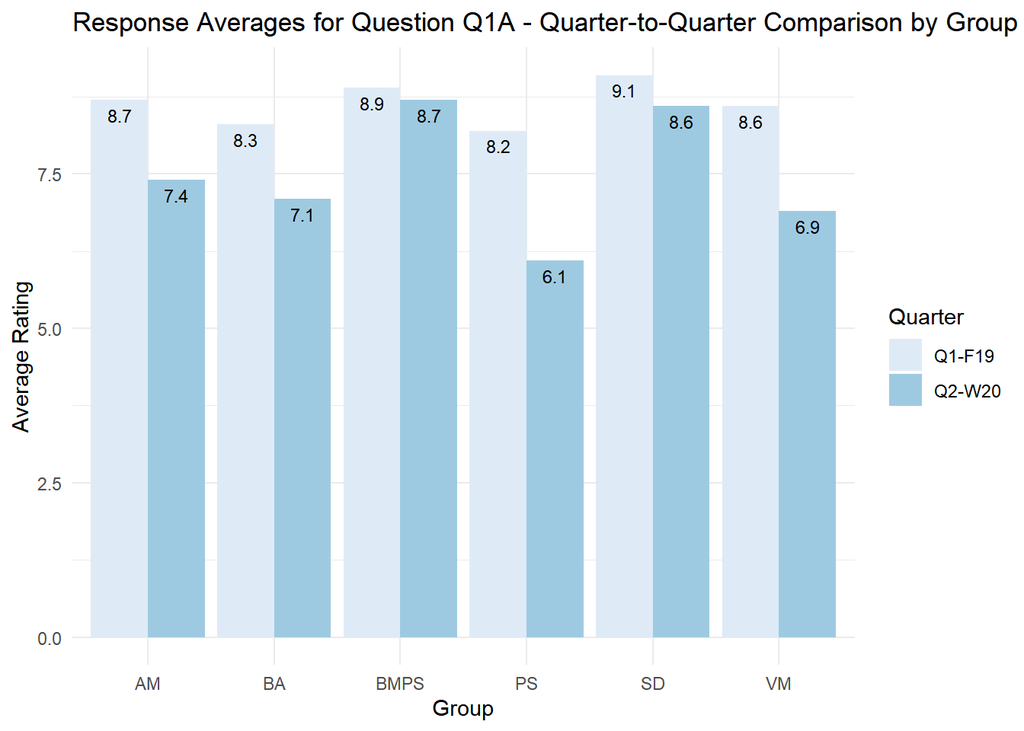

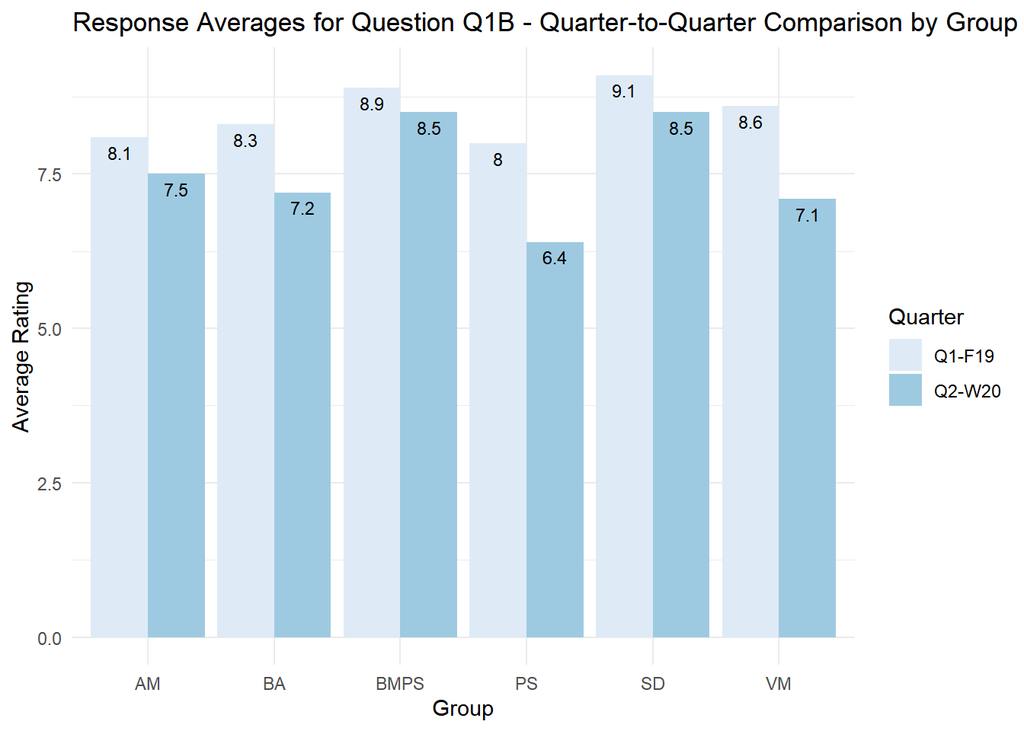

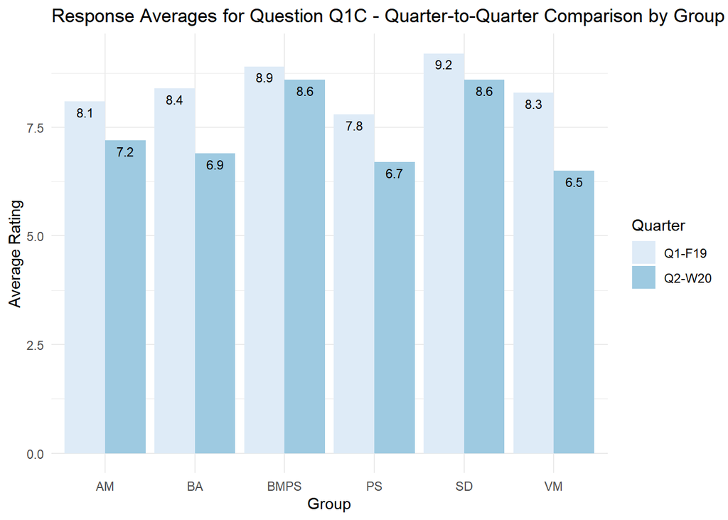

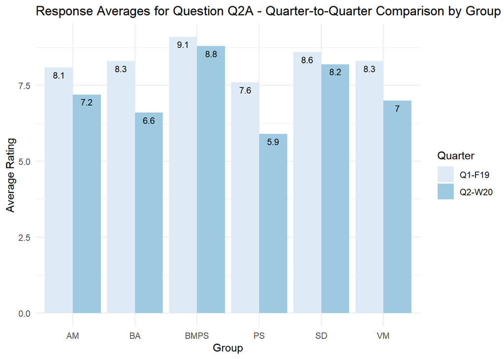

[2 more figures not shown]

[End of Report]